# Similarity Metric Distributions

Vanessa Sochat

02/14/2015

This R Markdown will explore the distributions of scores for each of a set of reasonable similarity metrics for one unthresholded map for a set of 16 different thresholds. First let’s link to all our metrics, in case we need:

- [covariance](https://github.com/vsoch/brainmeta/blob/master/image_comparison/experiments/similarity_metrics.py#L122)
- [correlation coefficient](https://github.com/nipy/nipy/blob/master/nipy/algorithms/registration/similarity_measures.py#L144)
- [correlation ratio](https://github.com/nipy/nipy/blob/master/nipy/algorithms/registration/similarity_measures.py#L171)
- [correlation ratio norm](https://github.com/nipy/nipy/blob/master/nipy/algorithms/registration/similarity_measures.py#L194)
- [mutual information norm](https://github.com/nipy/nipy/blob/master/nipy/algorithms/registration/similarity_measures.py#L129)
- [mutual information](https://github.com/nipy/nipy/blob/master/nipy/algorithms/registration/similarity_measures.py#L95)
- [cosine](https://github.com/scipy/scipy/blob/master/scipy/spatial/distance.py#L290)
- [euclidean](https://github.com/scipy/scipy/blob/master/scipy/spatial/distance.py#L222)
- [standardized euclidean](https://github.com/scipy/scipy/blob/master/scipy/spatial/distance.py#L448)
- [squared euclidean](https://github.com/scipy/scipy/blob/master/scipy/spatial/distance.py#L249)
- [chebyshev](https://github.com/scipy/scipy/blob/master/scipy/spatial/distance.py#L570)
- [canberra](https://github.com/scipy/scipy/blob/master/scipy/spatial/distance.py#L612)
- [braycurtis](https://github.com/scipy/scipy/blob/master/scipy/spatial/distance.py#L577)
- [linear kernel](https://github.com/scikit-learn/scikit-learn/blob/master/sklearn/metrics/pairwise.py#L662)
- [l1 kernel (taxicab/manhattan)](https://github.com/scikit-learn/scikit-learn/blob/master/sklearn/metrics/pairwise.py#L426)
- [l2 kernel (euclidean)](https://github.com/scikit-learn/scikit-learn/blob/master/sklearn/metrics/pairwise.py#L136)
- [sigmoid kernel](https://github.com/scikit-learn/scikit-learn/blob/master/sklearn/metrics/pairwise.py#L711)
- [polynomail kernel](https://github.com/scikit-learn/scikit-learn/blob/master/sklearn/metrics/pairwise.py#L680)
- [rbf kernel](https://github.com/scikit-learn/scikit-learn/blob/master/sklearn/metrics/pairwise.py#L740)

I computed a lot of kernels, but I don’t totally understand them, so I’m not comfortable using them. Now we will read in our data:

```r
metrics = c("ID","covariance","correlation_coefficient","correlation_ratio","correlation_ratio_norm","mutual_information_norm","mutual_information","cosine","euclidean","minkowski","cityblock","seuclidean","sqeuclidean","chebyshev","canberra","braycurtis")

metric_df = read.csv("/home/vanessa/Documents/Work/BRAINMETA/IMAGE_COMPARISON/compiled_scores/134_0.0.tsv",sep="\t",stringsAsFactors=FALSE)
metric_df = metric_df[,which(colnames(metric_df) %in% metrics)]
```

Let’s visualize the distribution of each

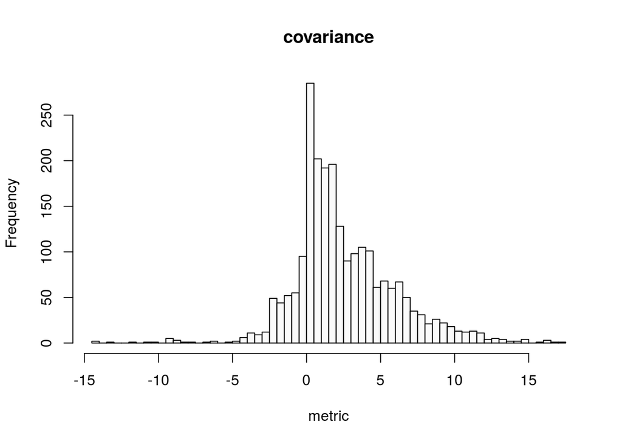

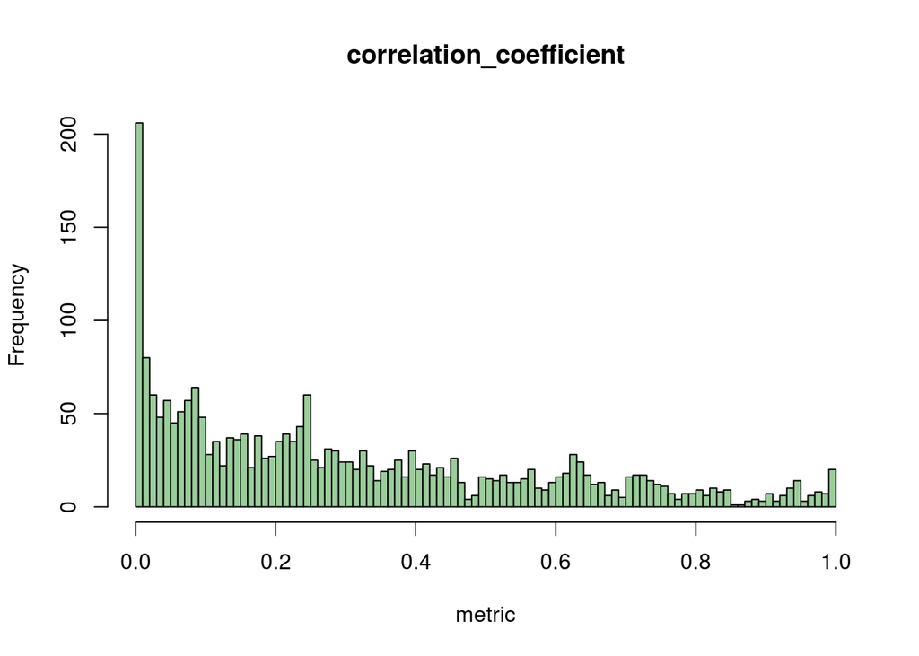

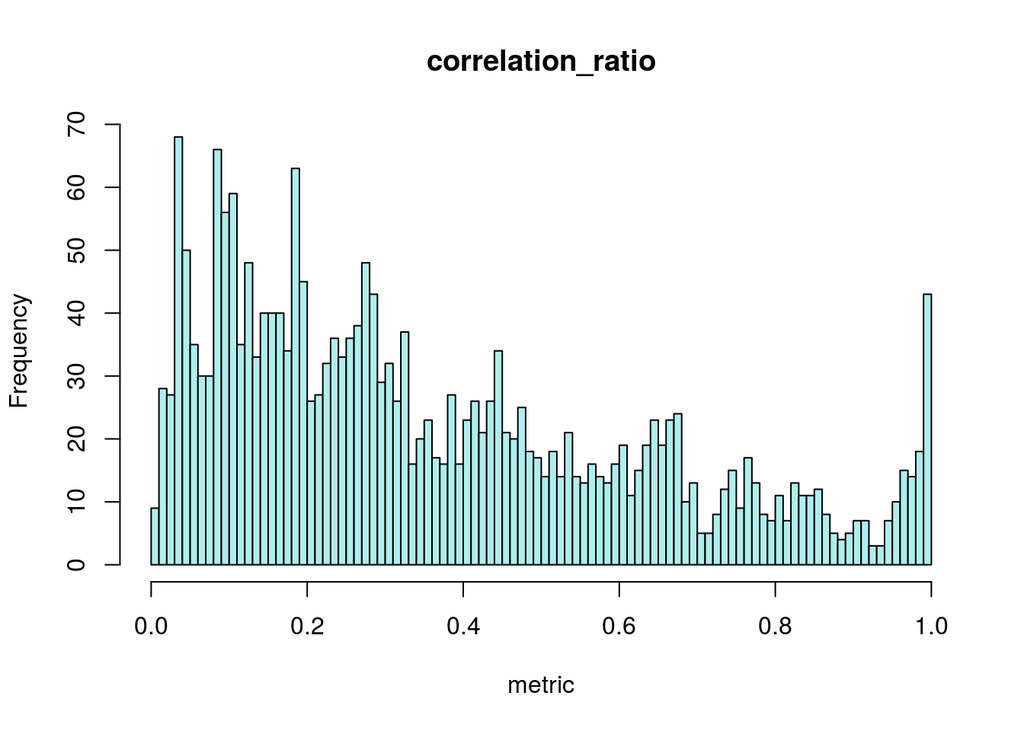

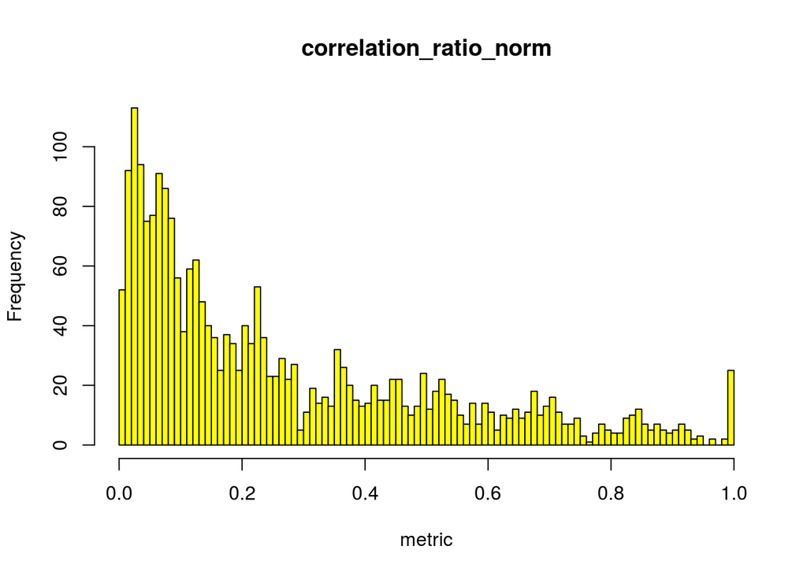

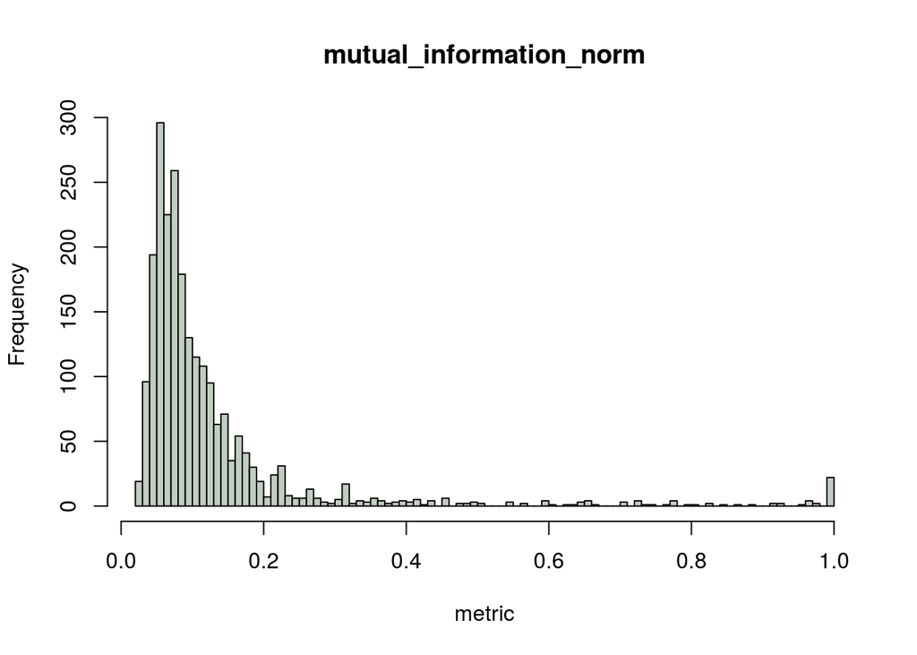

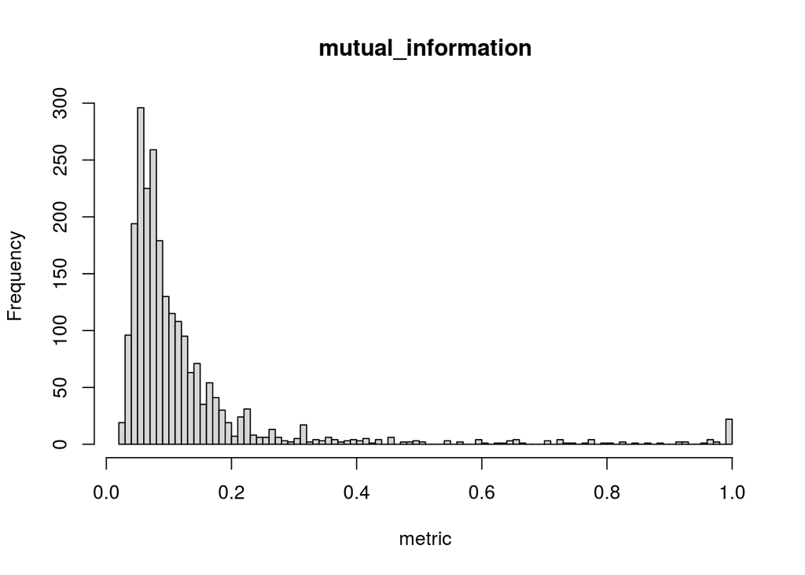

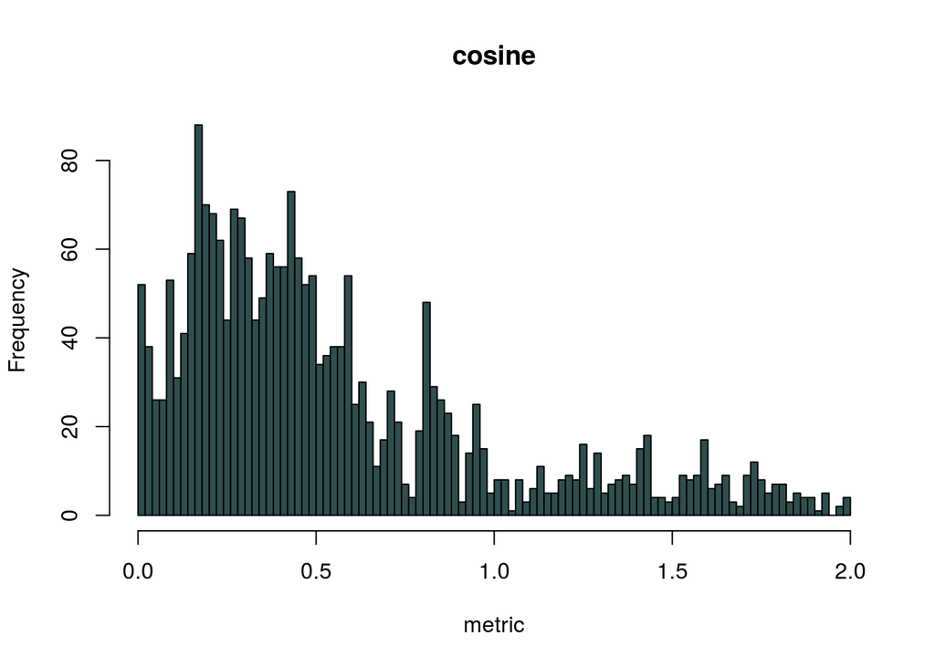

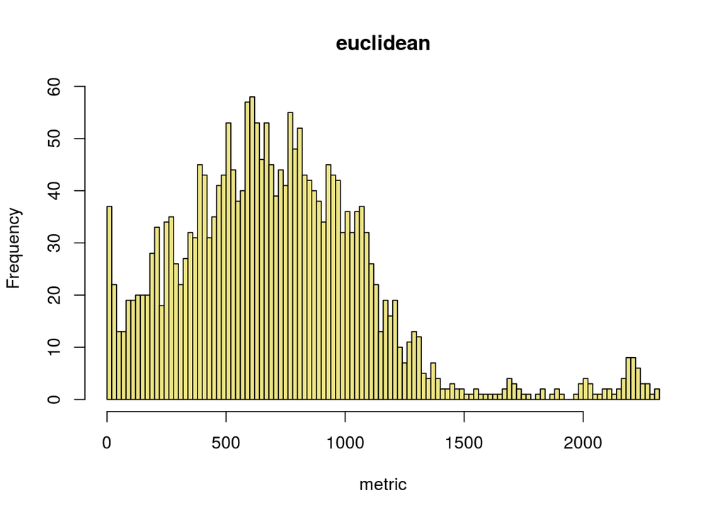

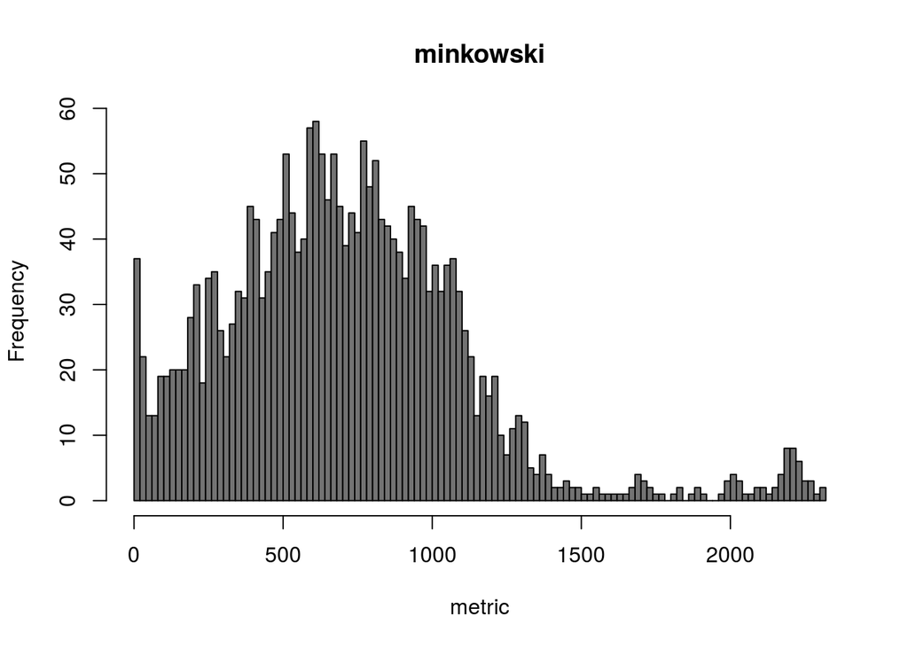

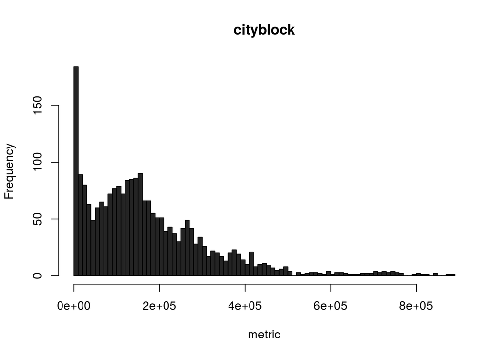

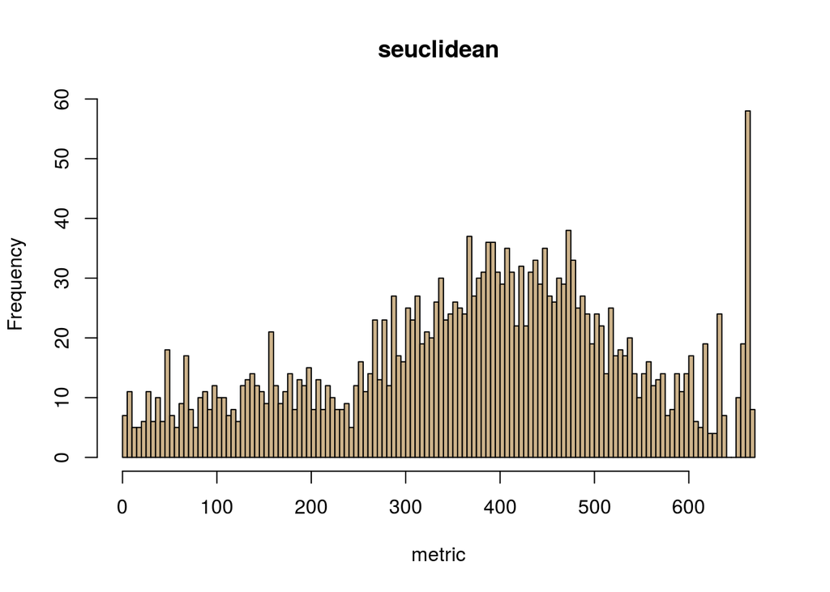

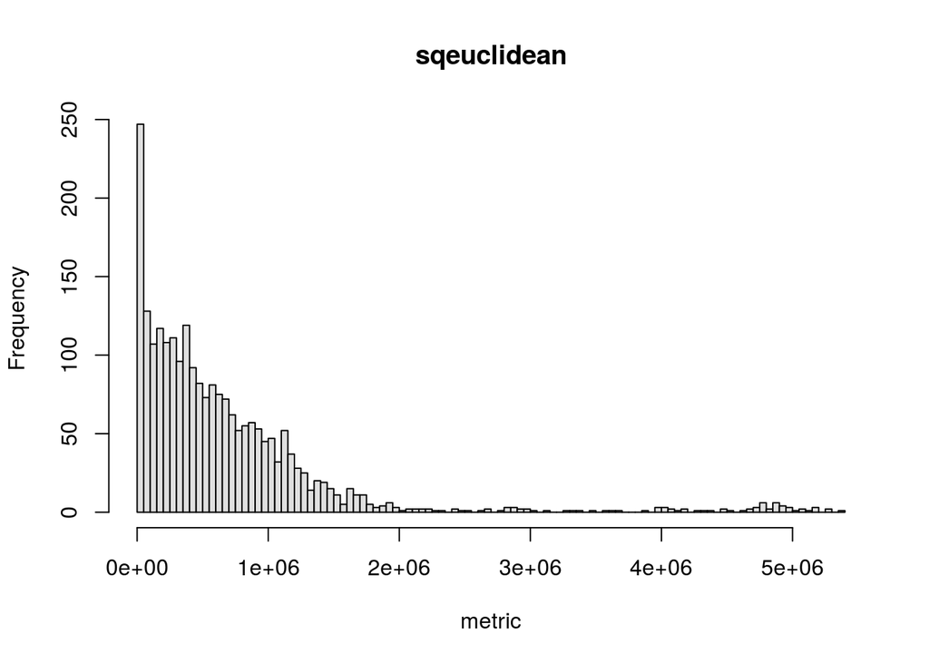

[3 more figures not shown]

```r
for (m in 2:ncol(metric_df)){
  metric = metric_df[!is.na(metric_df[,m]),m]
  hist(metric,col=sample(colours(),1),main=colnames(metric_df)[m],breaks=100)
}
```

This is exciting because the distributions look so different! Let’s create a vector that will have the ranked scores. We basically need to know which direction == more similar, and if we need to take an absolute value. I need some help with doing cosine - the values range from 0 to 2 (I believe they are in radians) and I interpret this as 1.5 radians == ~90 degrees, so technically values closer to 2 should be less similar, but the plot shows the opposite distribution to what I would expect. (Because in this space a value of 0 would == 0 degrees == pointing in same direction).

But actually, now that I’m looking at the euclidean distances, the cosine pattern could be reasonable. According to these metrics, there are much fewer pairs that are VERY different (on right side of plot), many that are “kind of” different (big clump in the middle), and a medium number of more similar (left). These metrics are probably just pretty bad toward this goal - we will see :)

I also realize that chebyshev possibly makes no sense (it is the maximum of the vectors distance in any direction, which means that the “gold standard” will always be equal to the actual).

Also - [canberra distance](http://en.wikipedia.org/wiki/Canberra_distance) is a metric for comparing ranked lists - I could use this possibly in scoring.

```r
# This function will return a list of ranked scores with names corresponding to image ids
do_ranking = function(scores,labels,ranking_type){

  names(scores) = labels

  # High negative or positive = more similar
  if (ranking_type == "abs_high"){
    return(sort(abs(scores),decreasing=TRUE))
  # Low / negative == more similar
  } else if (ranking_type == "low") {
    return(sort(scores,decreasing=FALSE))
  # 0 == similar, positive or negative high values not
  } else if (ranking_type == "abs_low") {
    return(sort(abs(scores),decreasing=FALSE))
  # Standard sorting (high value == more similar)
  } else {
    return(sort(scores,decreasing=TRUE))
  }
}

metric_names = metrics[2:length(metrics)]
metrics_sorted = c()
metrics_sorted["covariance"] = list(do_ranking(metric_df[,"covariance"],metric_df[,"ID"],"abs_high"))
metrics_sorted["correlation_coefficient"] = list(do_ranking(metric_df[,"correlation_coefficient"],metric_df[,"ID"],"abs_high"))
metrics_sorted["correlation_ratio"] = list(do_ranking(metric_df[,"correlation_ratio"],metric_df[,"ID"],"abs_high"))
metrics_sorted["correlation_ratio_norm"] = list(do_ranking(metric_df[,"correlation_ratio_norm"],metric_df[,"ID"],"abs_high"))
metrics_sorted["mutual_information"] = list(do_ranking(metric_df[,"mutual_information"],metric_df[,"ID"],"abs_high"))
metrics_sorted["mutual_information_norm"] = list(do_ranking(metric_df[,"mutual_information_norm"],metric_df[,"ID"],"abs_high"))
metrics_sorted["cosine"] = list(do_ranking(metric_df[,"cosine"],metric_df[,"ID"],"low"))
metrics_sorted["euclidean"] = list(do_ranking(metric_df[,"euclidean"],metric_df[,"ID"],"low"))
metrics_sorted["sqeuclidean"] = list(do_ranking(metric_df[,"sqeuclidean"],metric_df[,"ID"],"low"))
#metrics_sorted["seuclidean"] = list(do_ranking(metric_df[,"seuclidean"],metric_df[,"ID"],"low"))
metrics_sorted["chebyshev"] = list(do_ranking(metric_df[,"chebyshev"],metric_df[,"ID"],"low"))
metrics_sorted["minkowski"] = list(do_ranking(metric_df[,"minkowski"],metric_df[,"ID"],"low"))
metrics_sorted["cityblock"] = list(do_ranking(metric_df[,"cityblock"],metric_df[,"ID"],"low"))
metrics_sorted["canberra"] = list(do_ranking(metric_df[,"canberra"],metric_df[,"ID"],"low"))
metrics_sorted["braycurtis"] = list(do_ranking(metric_df[,"braycurtis"],metric_df[,"ID"],"low"))
```

### Goals of the analysis

We want to identify kinds of metrics that are most robust to changes in thresholding across large sets of images. This means that if I have image A, I can define a “gold standard” comparison of image A to image B as some metric applied to compare the unthresholded maps in entirety. This will result in a score. A comparison metric that is robust to changes in thresholding means that thresholding image A should not drastically change the metric.

### Assumptions of the experiment

- We have selected a group of metrics that are reasonable. Reasonable means that we aren’t coming up with nonsense, and we are using already well-established metrics.
- We cannot compare the scores themselves between metrics, so we will compare change in rankings.

### Goals of this visualization

I will be using this workbook to help visualize the gold standard ranking for one of the 144 query images, and to develop a scoring algorithm. Then I can implement this algorithm across all 144 images, and summarize the result.

### Defining the gold standard

Now that we have ALL the values sorted, for each list of metrics, we can pull out the values thresholded at 0.0 to define the “gold standard” lists. Let’s write a function to do it:

```r
get_gold_standard = function(metric_sorted,image_id) {
  nothreshidx = grep("*0.0$",names(metric_sorted[[1]]))
  gs_set = metric_sorted[[1]][nothreshidx]
  # Here we can do a sanity check that the first value is the image we are looking at!
  if (!grepl(as.character(image_id),names(gs_set)[1])){
    cat("ERROR: first image is not most similar for metric",names(metric_sorted),"\n")
  } else {
    plot(gs_set,pch=19,col=heat.colors(length(gs_set)),main=paste("Ordered scores for GS",names(metric_sorted)))
    # Now we will fit the ranking to a color scale - we don't care about values anymore (for now)
    # We will assume that a slight threshold on an image would rank it just below the image w/o threshold
    gs_image_id = gsub("_thr_0.0","",names(gs_set))
    gs_labels = c()
    # Derive the labels from the data in the case of any nans eliminating options
    for (id in gs_image_id){
      thresholds = sort(gsub(paste(id,"_thr_",sep=""),"",names(metric_sorted[[1]][grep(id,names(metric_sorted[[1]]))])))
      gs_labels = c(gs_labels,paste(id,"_thr_",thresholds,sep=""))
    }
    gs_order = seq(1,length(gs_labels))
    names(gs_order) = gs_labels
    # But now we need to account for
    return(list(gs_order))
  }
}
```

The function above will output a vector of number rankings according to the similiarty metric calculated for unthresholded maps, with additional spaces to allow for each thresholding.

```
## ERROR: first image is not most similar for metric covariance
```

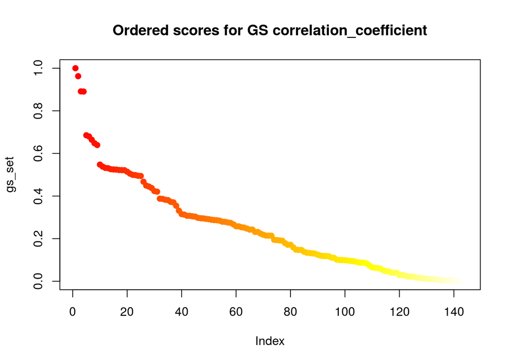

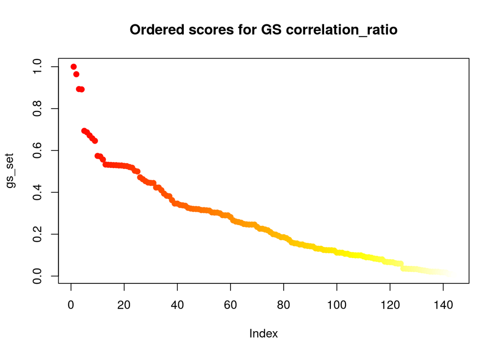

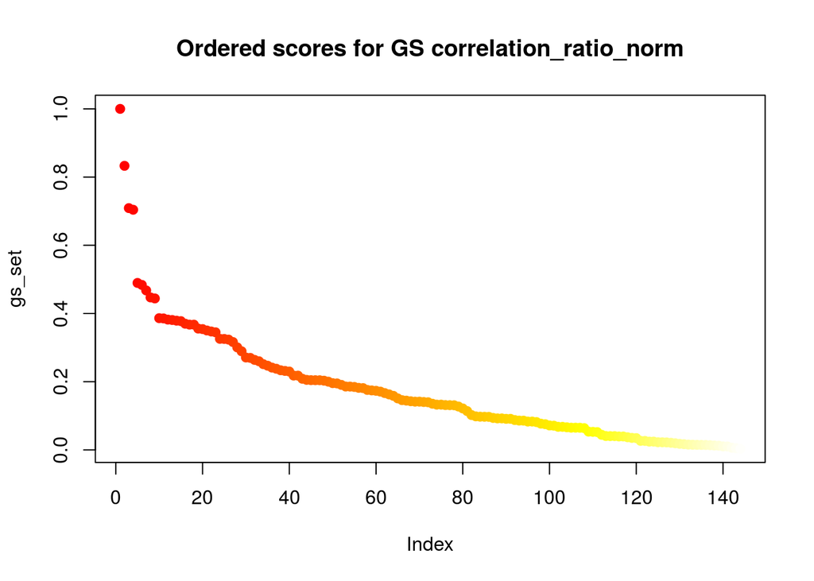

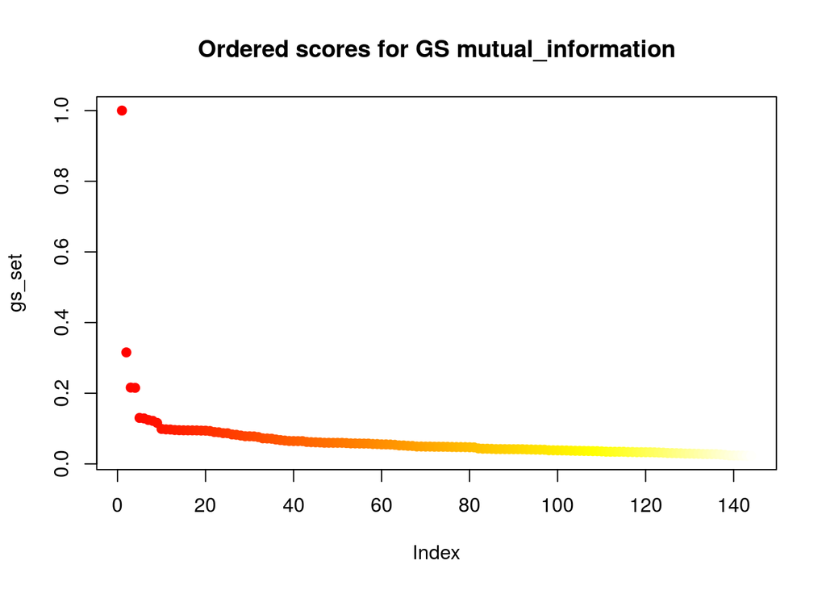

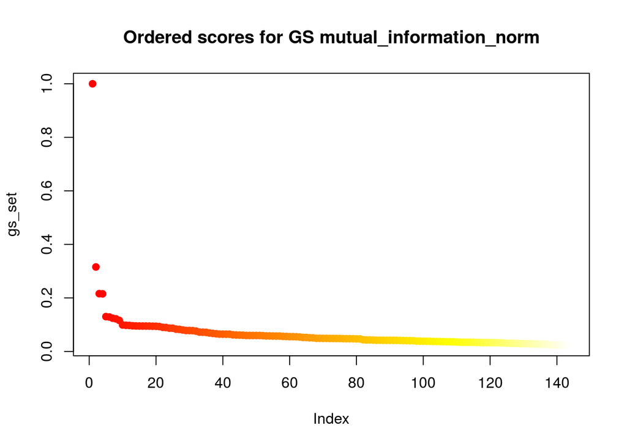

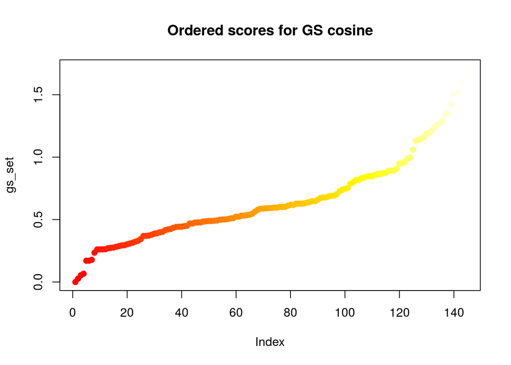

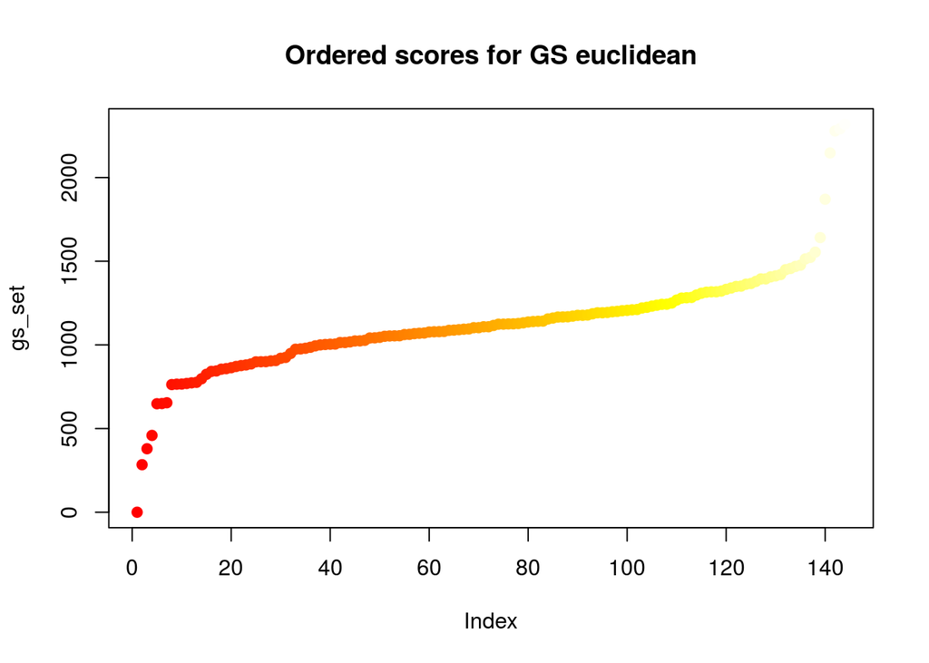

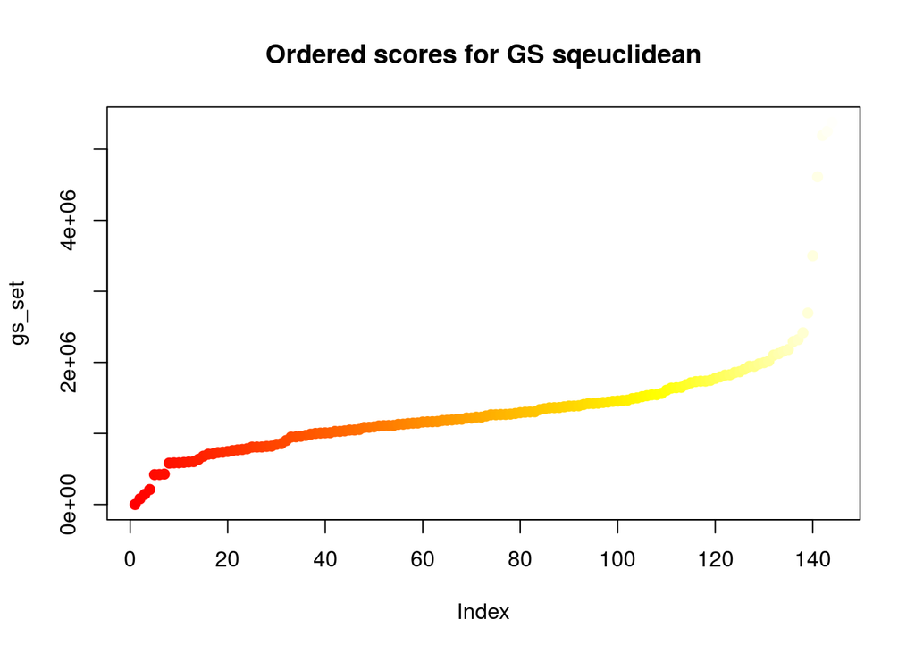

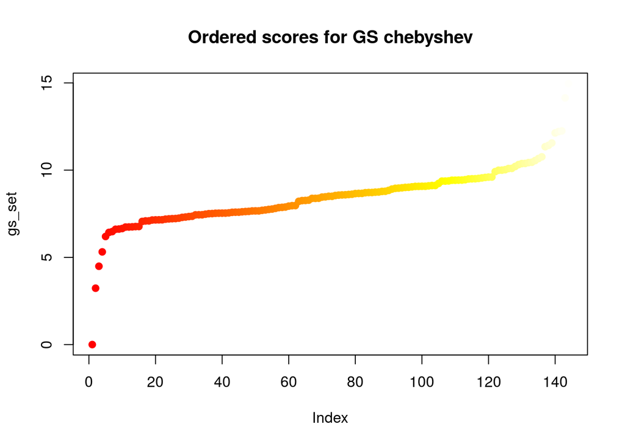

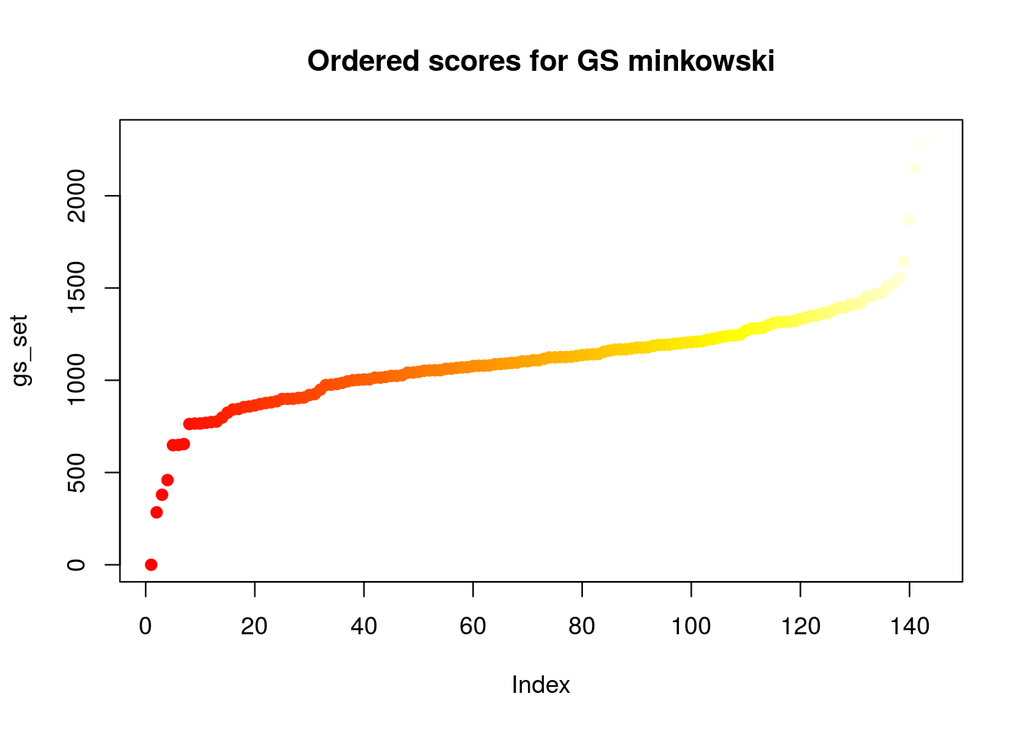

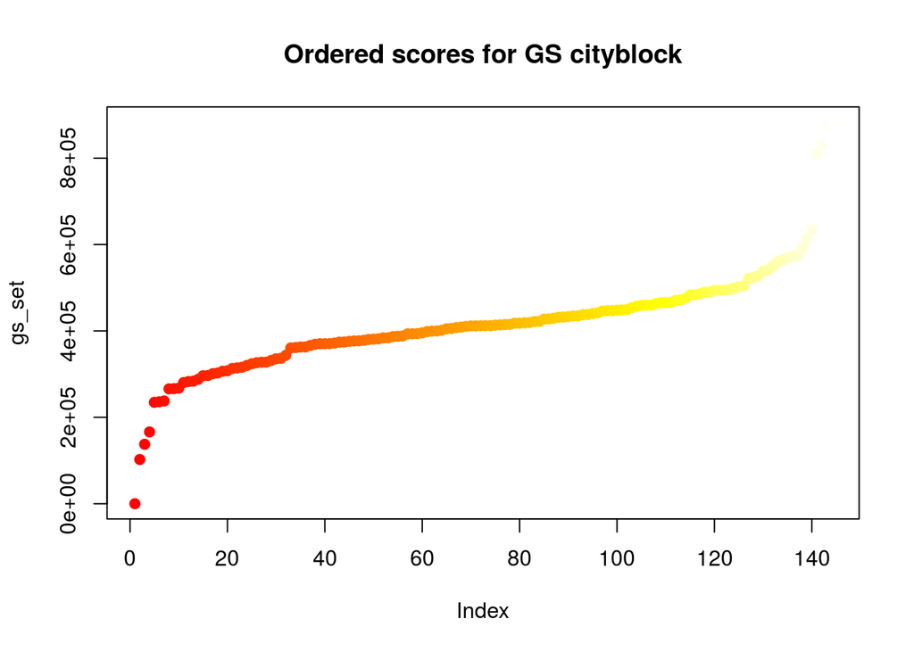

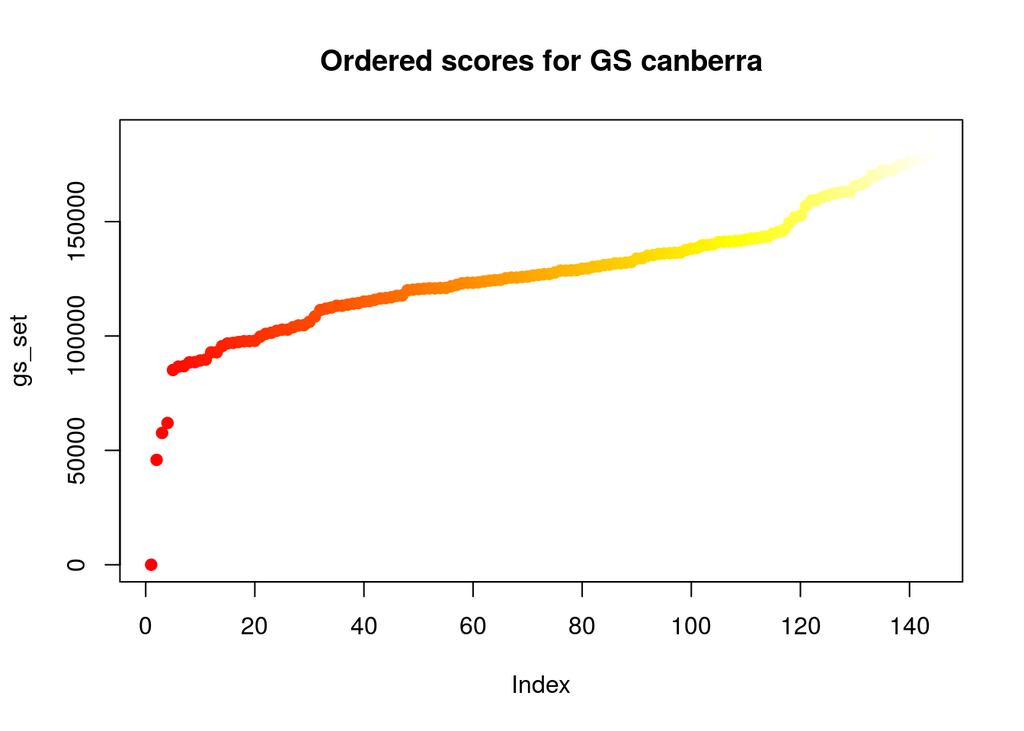

[1 more figures not shown]

```r
gs = c()
image_id=134
for (m in 1:length(metrics_sorted)){
  metric_name = names(metrics_sorted[m])
  gs[metric_name] = get_gold_standard(metrics_sorted[m],image_id)
}
```

### Calculating a score

Now we have, for each metric, a gold standard, and the actual list. We can now do two things:

1. write a basic function to calculate a score. I am going to start super simple - I will sum the distances that each actual image@ particular threshold is away from the gold standard.
2. Visually compare each metric ordering vs. the gold standard - two columns for each metric